# Business Data analytics Group 6- Show/No Show classification

### Import data and set objective

```r
if (!require("pacman")) install.packages("pacman")
pacman::p_load("knitr")

knitr::opts_knit$set(root.dir = "~/source/big_data/Group6/datasets")
df.train <- read.csv("../datasets/NS.TRAIN.csv")
df.test <- read.csv("../datasets/NS.TEST.csv")
```

Importing the splitted DFs.

```r
dim(df.train)
```

```
## [1] 88416    35
```

```r
table(is.na(df.train))
```

```
##
##   FALSE
## 3094560
```

The train DF holds 88416x35 rows and attributes(columns)

##### Split Train to 50/50 show/no show

```r
dim(df.train[df.train$no_show==0,])
```

```
## [1] 70520    35
```

```r
dim(df.train[df.train$no_show==1,])
```

```
## [1] 17896    35
```

We’re holding 70K shows and 17K no shows. this will cause the model to be baised.. and we don’t want that!

```r
df.no_show <- sample(df.train[df.train$no_show==1,])
df.show <- sample(df.train[df.train$no_show==0,])
df.train.balanced <- rbind(df.no_show, df.show[1:17896,])
dim(df.train.balanced)
```

```
## [1] 35792    35
```

Now we’re having a balanced DF with 50%/50% shows/no shows

```r
dim(df.train.balanced[df.train.balanced$no_show==0,])
```

```
## [1] 17896    35
```

```r
dim(df.train.balanced[df.train.balanced$no_show==1,])
```

```
## [1] 17896    35
```

### EDA

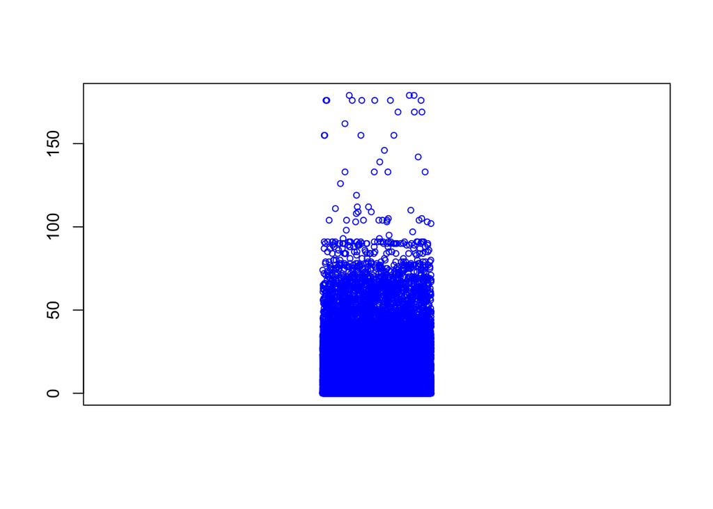

```r
stripchart(df.train.balanced$waiting_time, method = "jitter",  vertical = TRUE, col ="blue",cex = 0.75, pch= 1)
```

We can see that we have some outliers in the waiting time feature. Hence, we’ll compress the over 90 days waiting tome to group of 90 days waiting time.

#### Split data by waiting time ranges

```
## [1] "X = 0.158678245178753"
```

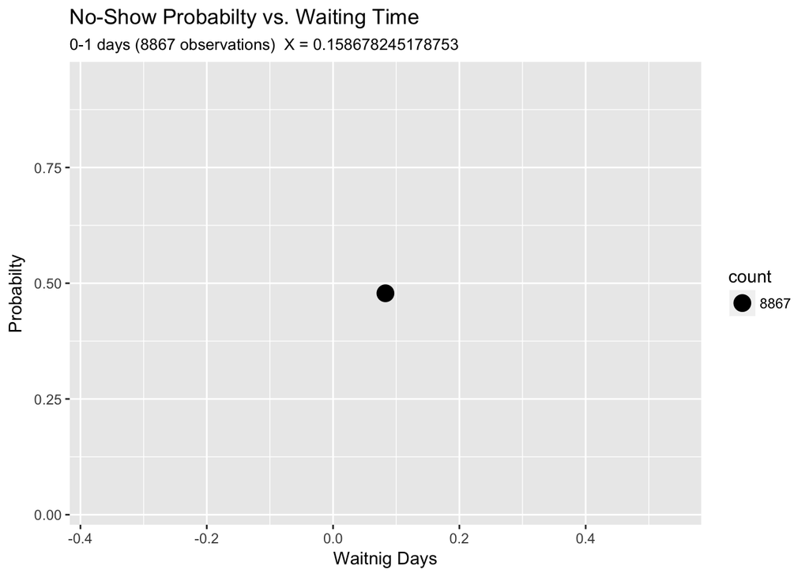

```r
#Draw
#install.packages("ggplot")
library("ggplot2")
draw_waiting_days_gg(0,1)
```

```
## [1] "X = 0.546023559071751 + 0.00619923231024794 * Y"
```

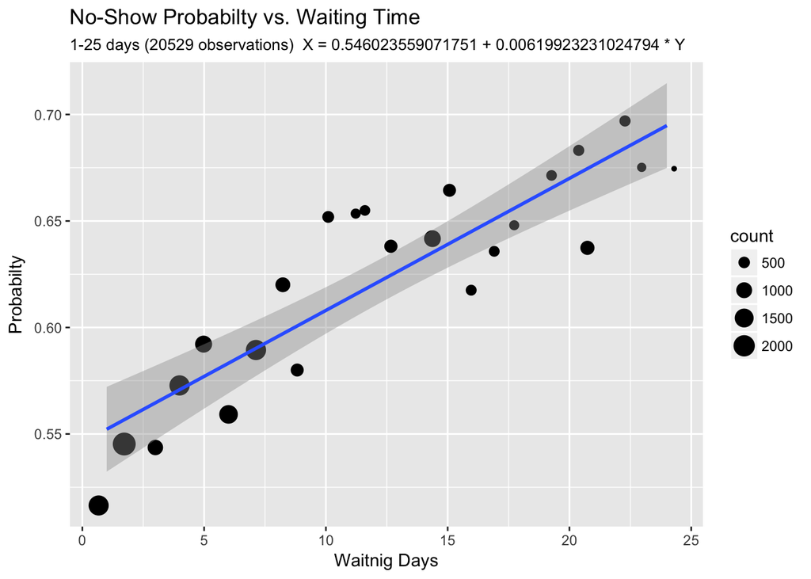

```r
draw_waiting_days_gg(1,25)
```

```
## [1] "X = 0.685684913764639 - 0.000608071730208754 * Y"
```

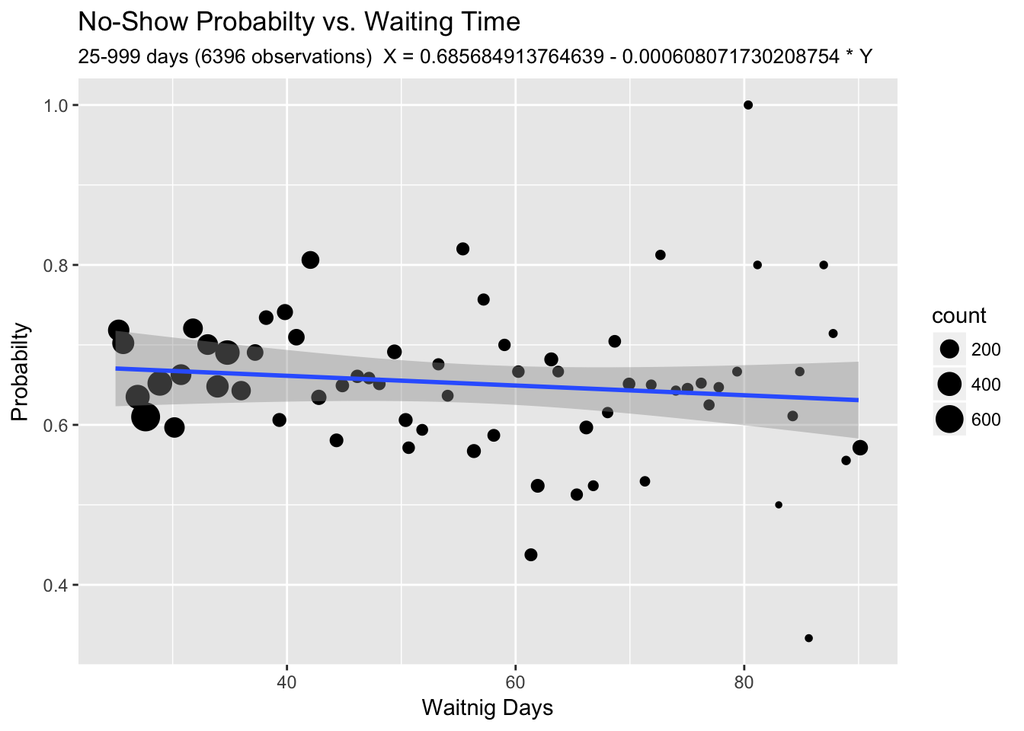

```r
draw_waiting_days_gg(25,999)
```

```r
# draw_waiting_days_gg(25,90)
# draw_waiting_days_gg(90,135)
# draw_waiting_days_gg(135,999)
```

```r
prob_calc_waiting_time_full <- function(days)
{
  if (days == 0) {
    0.0456610631531122
    } else if  (days >=1 & days < 25) {
    0.230756030998989 + (0.0055475902127787 * days)
    } else {
    0.36577378261591 - (0.000851467844045281 * days)
    }
}

prob_calc_waiting_time <- function(days)
{
  if (days == 0) {
    0.158678245178753
    } else if  (days >=1 & days < 25) {
    0.546023559071751 + (0.00619923231024794 * days)
    } else {
    0.685684913764639 - (0.000608071730208754 * days)
    }
}


df.train.balanced$prob_waiting_time <- prob_calc_waiting_time(df.train.balanced$waiting_time)
df.test$prob_waiting_time <- prob_calc_waiting_time(df.test$waiting_time)
df.train$prob_waiting_time_full <- prob_calc_waiting_time_full(df.train$waiting_time)
df.test$prob_waiting_time_full <- prob_calc_waiting_time_full(df.test$waiting_time)
```

Outliers for Age feature. we can see that we have several ages that are beyond 85 y.o and the number of occurrence is not high, hence, we’ll compress them to the age of 85

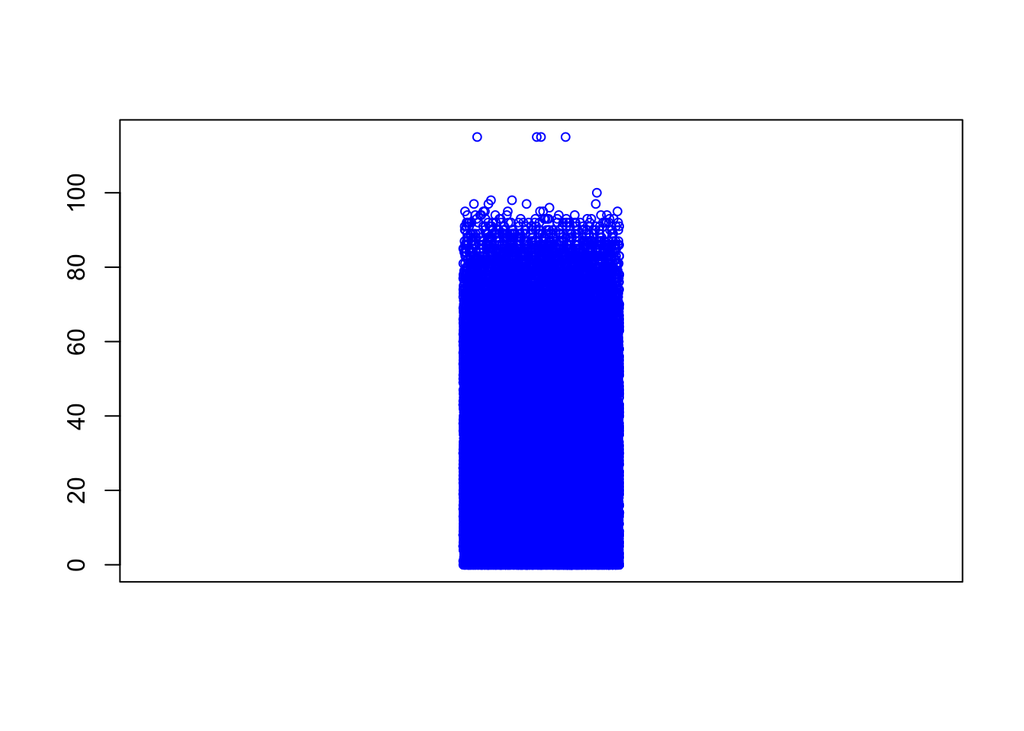

```r
stripchart(df.train.balanced$age, method = "jitter",  vertical = TRUE, col ="blue",cex = 0.75, pch= 1)
```

#### Split data by age ranges

```
## [1] "X = 0.462765564615094 + 0.00801267576660286 * Y"
```

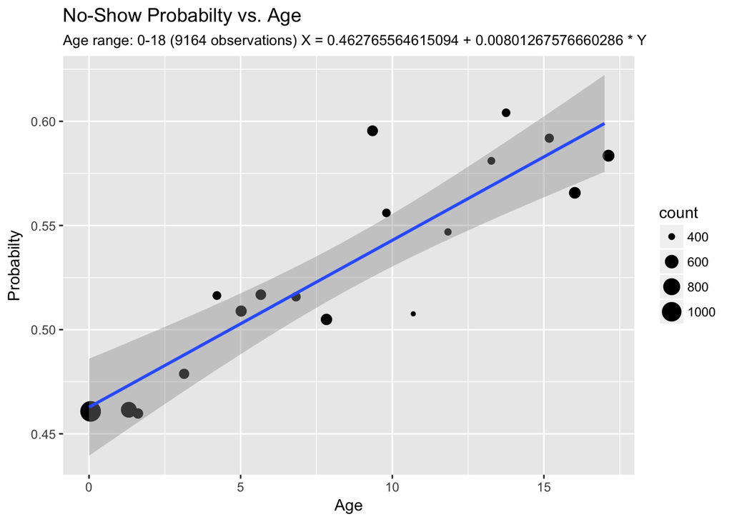

```r
#Draw
draw_age_gg(0,18)
```

```
## [1] "X = 0.655580418512068 - 0.0037080855647871 * Y"
```

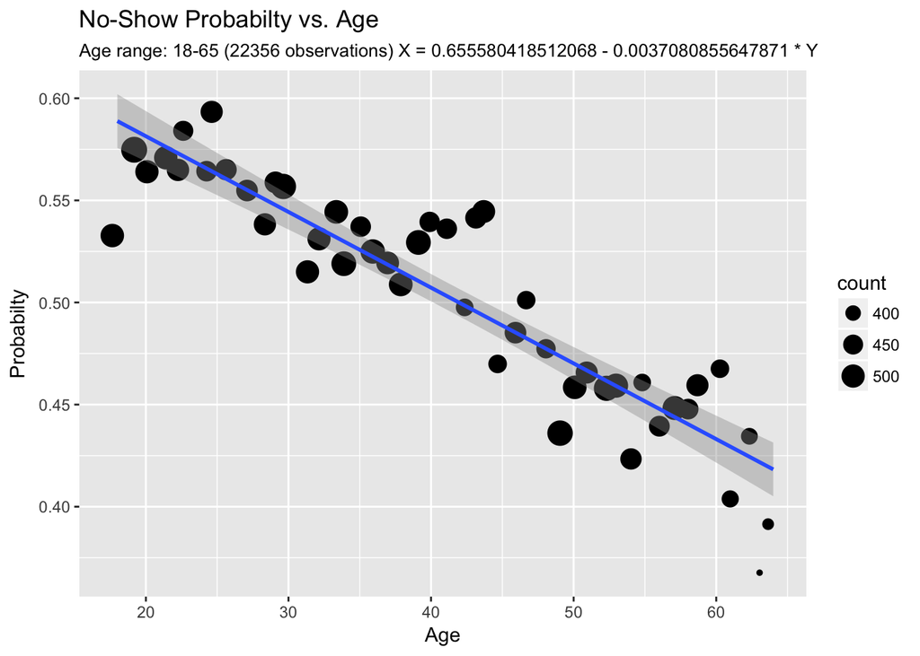

```r
draw_age_gg(18,65)
```

```
## [1] "X = 0.411559081661147 + 8.19162277192257e-05 * Y"
```

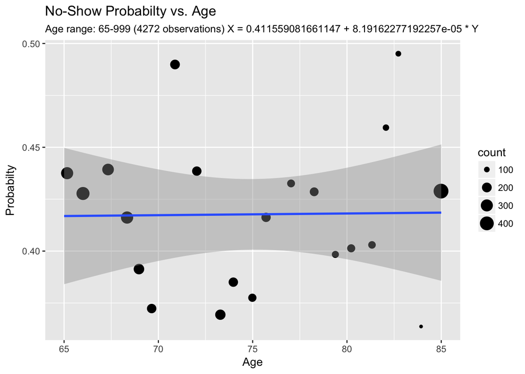

```r
draw_age_gg(65,999)
```

```r
# draw_age_gg(65,85)
# draw_age_gg(85,999)
```

```r
prob_calc_age_full <- function(age)
{
  if (age<18) {
    0.173782901236029 + 0.00626848946448816 * age
    } else if  (days >=18 & days < 65) {
    0.306786971869277 - 0.00244909445437991 * age
    } else {
    0.0910425992387074 + 0.000864371687591228 * age
    }
}

prob_calc_age <- function(age)
{
  if (age<18) {
    0.462765564615094 + 0.00801267576660286 * age
    } else if  (days >=18 & days < 65) {
    0.655580418512068 - 0.0037080855647871 * age
    } else {
    0.411559081661147 + 0.00008191622771923 * age
    }
}

df.train.balanced$prob_age <- prob_calc_waiting_time(df.train.balanced$age)
df.test$prob_age <- prob_calc_waiting_time(df.test$age)
df.train$prob_age_full <- prob_calc_waiting_time_full(df.train$age)
df.test$prob_age_full <- prob_calc_waiting_time_full(df.test$age)
```

### Scaling and modeling

After we looked on the data, let’s start building some models and start look for a proper model to our problem.

```r
df.train.balanced$age_scaled <- df.train.balanced$age / max(df.train.balanced$age)
df.train.balanced$waiting_time_scaled <- df.train.balanced$waiting_time / max(df.train.balanced$waiting_time)

df.test$age_scaled <- df.test$age / max(df.test$age)
df.test$waiting_time_scaled <- df.test$waiting_time / max(df.test$waiting_time)
```

Since we’re dealing with binary values in most of our data, we would like to scale waiting_time and age features to be at the same scale. Hence, we’ve boundered them into 0-1

#### Logistic Model

```r
logit_model <- glm(no_show ~ age_scaled+
                         waiting_time_scaled+
                         scholarship+
                         sms_recieved, data = df.train.balanced, family = binomial)
summary (logit_model)
```

```
##
## Call:
## glm(formula = no_show ~ age_scaled + waiting_time_scaled + scholarship +
##     sms_recieved, family = binomial, data = df.train.balanced)
##
## Deviance Residuals:
##     Min       1Q   Median       3Q      Max
## -2.3506  -1.0636  -0.2505   1.1388   1.5483
##
## Coefficients:
##                     Estimate Std. Error z value Pr(>|z|)
## (Intercept)         -0.24577    0.02352 -10.451  < 2e-16 ***
## age_scaled          -0.59381    0.04143 -14.334  < 2e-16 ***
## waiting_time_scaled  2.64255    0.07670  34.453  < 2e-16 ***
## scholarship          0.21902    0.03574   6.127 8.93e-10 ***
## sms_recieved         0.35668    0.02421  14.735  < 2e-16 ***
## ---
## Signif. codes:  0 '***' 0.001 '**' 0.01 '*' 0.05 '.' 0.1 ' ' 1
##
## (Dispersion parameter for binomial family taken to be 1)
##
##     Null deviance: 49618  on 35791  degrees of freedom
## Residual deviance: 47150  on 35787  degrees of freedom
## AIC: 47160
##
## Number of Fisher Scoring iterations: 4
```

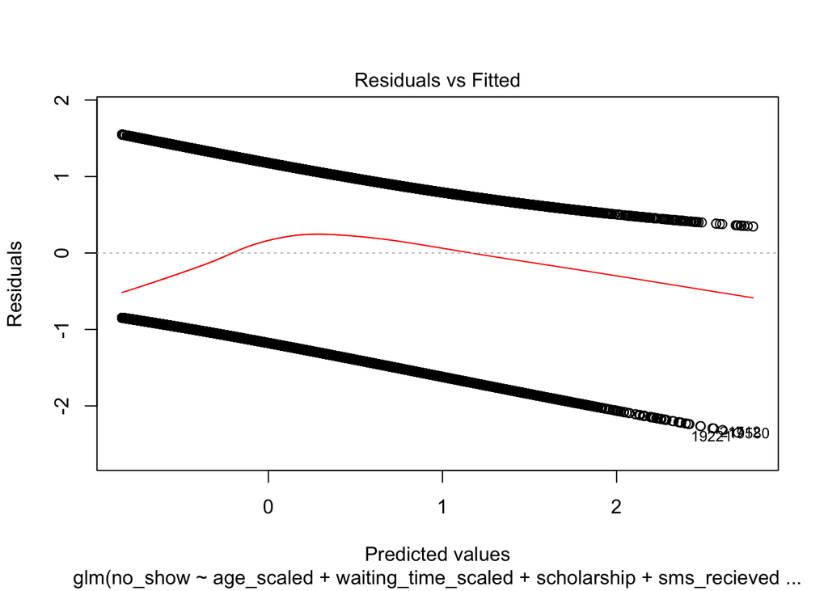

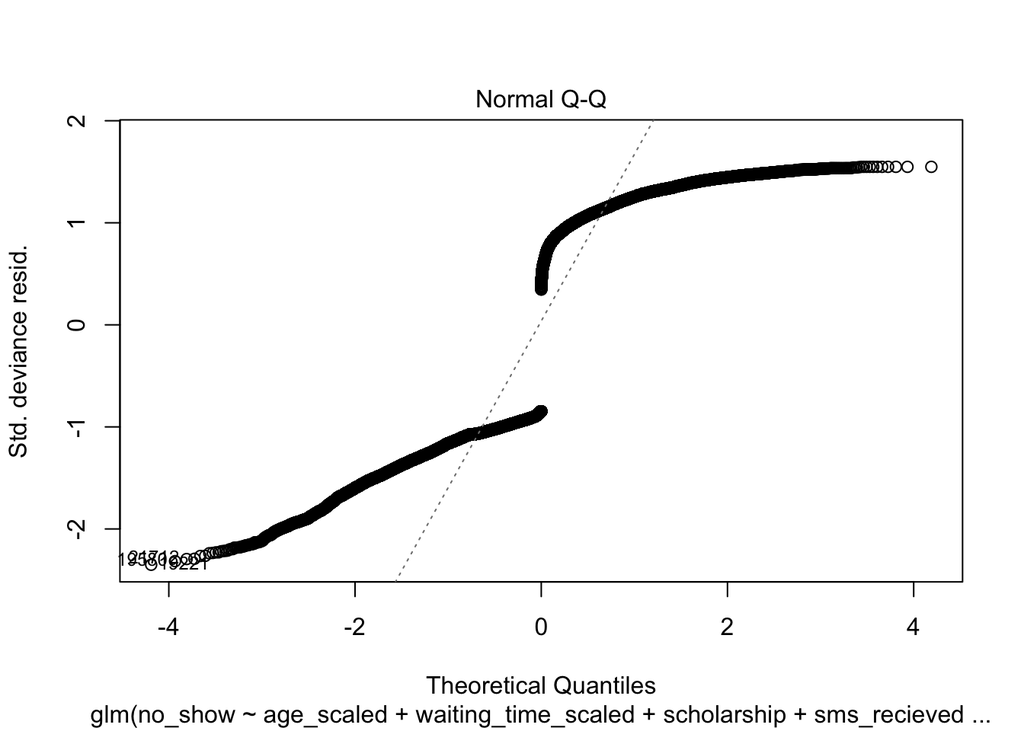

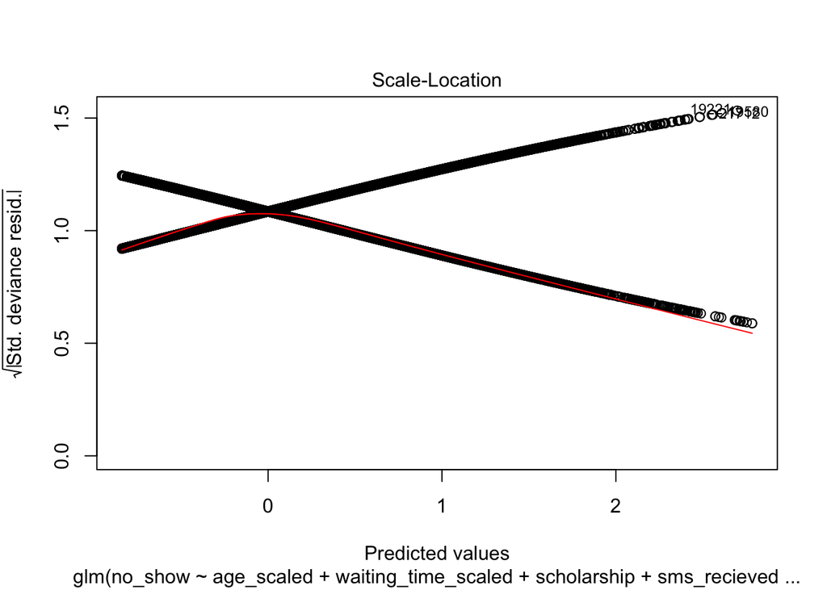

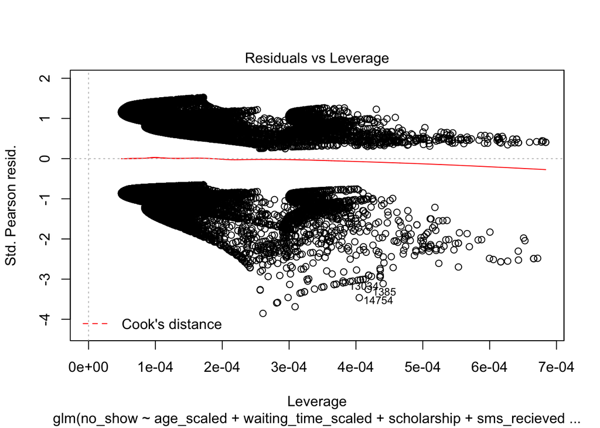

```r
plot(logit_model)
```

```r
#
# logit_model_full <- glm(no_show ~ prob_age_full+
#                          prob_waiting_time_full, data = df.train, family = binomial)
```

#### CART

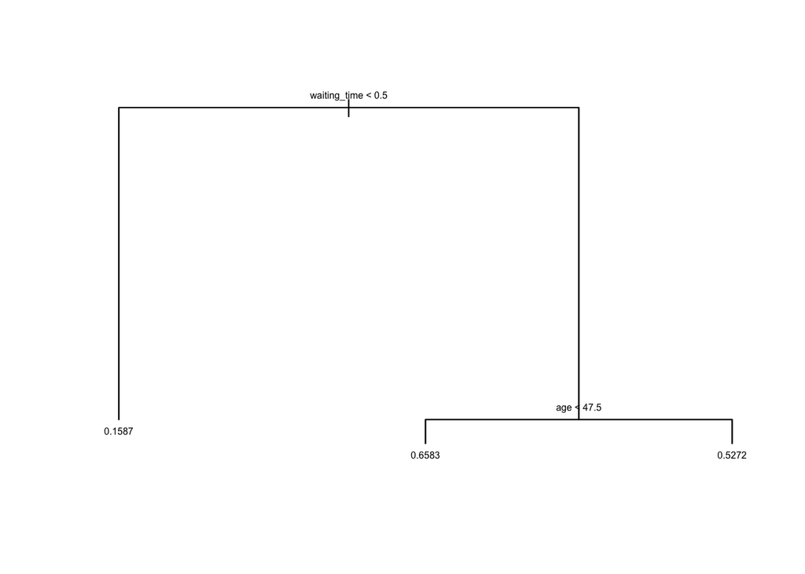

```r
pacman::p_load("tree")
noshow.CART <- tree(no_show ~ week_day+
                      waiting_time+
                      age+
                      is_female+
                      scholarship+
                      hipertension+
                      diabetes+
                      alcoholism+
                      handcap+
                      sms_recieved+
                      poverty+
                      region ,data = df.train.balanced)
plot(noshow.CART)
text(noshow.CART, pretty = 0, cex=0.5)
```

```r
summary(noshow.CART)
```

```
##
## Regression tree:
## tree(formula = no_show ~ week_day + waiting_time + age + is_female +
##     scholarship + hipertension + diabetes + alcoholism + handcap +
##     sms_recieved + poverty + region, data = df.train.balanced)
## Variables actually used in tree construction:
## [1] "waiting_time" "age"
## Number of terminal nodes:  3
## Residual mean deviance:  0.2087 = 7470 / 35790
## Distribution of residuals:
##     Min.  1st Qu.   Median     Mean  3rd Qu.     Max.
## -0.65830 -0.52720  0.09154  0.00000  0.34170  0.84130
```

#### Random Forest

```r
pacman::p_load("randomForest")
set.seed(7)
noshow.RF <- randomForest(no_show ~ week_day
                          +waiting_time
                          +age
                          +is_female
                          +scholarship
                          +sms_recieved
                          +poverty
                          +region
                          , data = df.train.balanced, na.action=na.omit, type="classification", ntree=100)
```

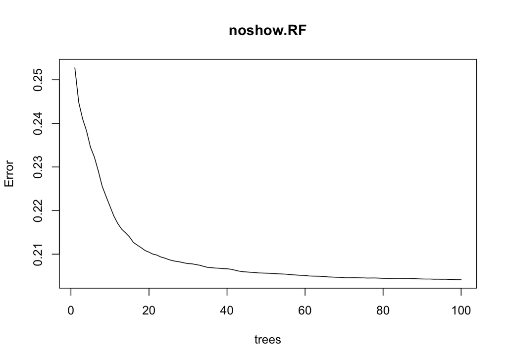

```r
plot(noshow.RF)
```

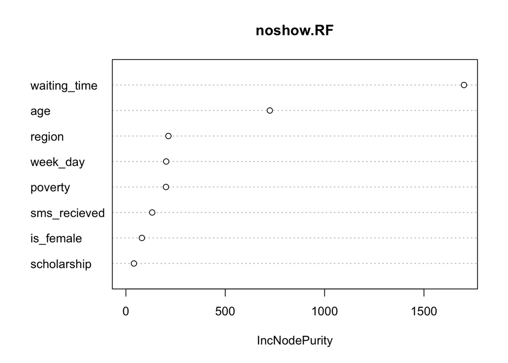

```r
#importance(noshow.RF)
varImpPlot(noshow.RF)
```

#### Gradient Boosting Machine

```r
# install.packages("gbm",repos = "http://cran.us.r-project.org")
#library("gbm")
pacman::p_load("gbm")
set.seed(7) #same seed to repeat the RF
no_show.gbm <- gbm (no_show ~ week_day+
                         waiting_time+
                         age+
                         is_female+
                         scholarship+
                         sms_recieved+
                         poverty+
                         region ,data = df.train.balanced, n.trees = 1000, interaction.depth = 4, shrinkage = 0.2, verbose = F)
```

```
## Distribution not specified, assuming bernoulli ...
```

```r
no_show.gbm
```

```
## gbm(formula = no_show ~ week_day + waiting_time + age + is_female +
##     scholarship + sms_recieved + poverty + region, data = df.train.balanced,
##     n.trees = 1000, interaction.depth = 4, shrinkage = 0.2, verbose = F)
## A gradient boosted model with bernoulli loss function.
## 1000 iterations were performed.
## There were 8 predictors of which 8 had non-zero influence.
```

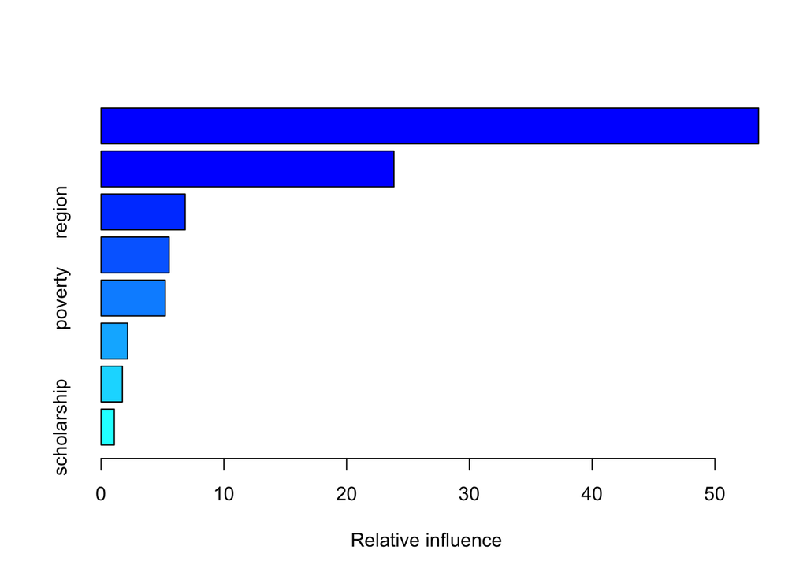

```
##                       var   rel.inf
## waiting_time waiting_time 53.555724
## age                   age 23.856030
## region             region  6.850661
## week_day         week_day  5.541479
## poverty           poverty  5.228947
## sms_recieved sms_recieved  2.160690
## is_female       is_female  1.730464
## scholarship   scholarship  1.076004
```

```r
summary(no_show.gbm)
```

### Model evaluation

#### Logistic Model

```r
threshold = 0.5
fitted.lm.results <- predict(logit_model,df.test,type='response')
lm.prediction <- ifelse(fitted.lm.results > threshold,1,0)
lm.accuracy <- mean(lm.prediction == df.test$no_show)
lm.accuracy
```

```
## [1] 0.6965392
```

```r
# fitted.lm.results_full <- predict(logit_model_full,df.test,type='response')
# lm.prediction_full <- ifelse(fitted.lm.results_full > threshold,1,0)
# lm.accuracy_full <- mean(lm.prediction_full == df.test$no_show)
# lm.accuracy_full
```

```r
#install.packages("caret",repos = "http://cran.us.r-project.org")
#library("caret")
#install.packages("e1071",repos = "http://cran.us.r-project.org")
#library("e1071")
pacman::p_load("caret")
pacman::p_load("e1071")
confusionMatrix(data = lm.prediction, reference =  df.test$no_show)
```

```
## Confusion Matrix and Statistics
##
##           Reference
## Prediction     0     1
##          0 13432  2453
##          1  4255  1965
##
##                Accuracy : 0.6965
##                  95% CI : (0.6904, 0.7026)
##     No Information Rate : 0.8001
##     P-Value [Acc > NIR] : 1
##
##                   Kappa : 0.1771
##  Mcnemar's Test P-Value : <2e-16
##
##             Sensitivity : 0.7594
##             Specificity : 0.4448
##          Pos Pred Value : 0.8456
##          Neg Pred Value : 0.3159
##              Prevalence : 0.8001
##          Detection Rate : 0.6076
##    Detection Prevalence : 0.7186
##       Balanced Accuracy : 0.6021
##
##        'Positive' Class : 0
##
```

```r
cross.table <- table(lm.prediction, df.test$no_show)
l <- nrow(cross.table)
if(l< 2)  {
          cross.table <- rbind(cross.table, c(0,0))
          }
accuracy <- (cross.table[1,1]+cross.table[2,2])/ (cross.table[1,1]+cross.table[2,2]+cross.table[1,2]+cross.table[2,1])
precision <- cross.table[2,2]/(cross.table[2,2]+cross.table[2,1])
recall <- cross.table[2,2]/(cross.table[2,2]+cross.table[1,2])
f1 <- 2*(recall*precision)/(recall+precision)

paste("Accuracy -",accuracy)
```

```
## [1] "Accuracy - 0.696539244514816"
```

```r
paste("Precision -",precision)
```

```
## [1] "Precision - 0.315916398713826"
```

```r
paste("Recall -",recall)
```

```
## [1] "Recall - 0.444771389769126"
```

```r
paste("F1 -",f1)
```

```
## [1] "F1 - 0.369430344049633"
```

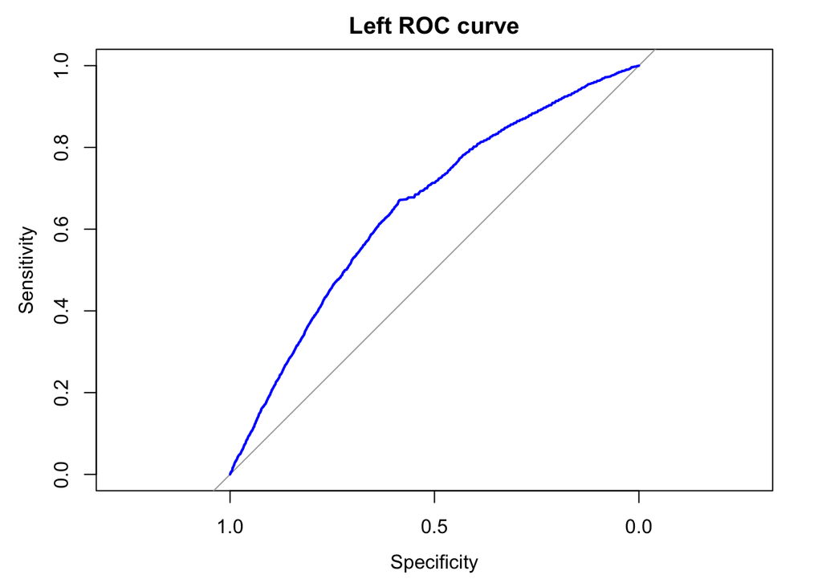

```r
#install.packages("pROC",repos = "http://cran.us.r-project.org")
pacman::p_load("pROC")
plot(roc(df.test$no_show, fitted.lm.results, direction="<"), col="blue", main="Left ROC curve")
```

#### CART

```r
threshold = 0.6
fitted.cart.results <- predict(noshow.CART,df.test)
summary(fitted.cart.results)
```

```
##    Min. 1st Qu.  Median    Mean 3rd Qu.    Max.
##  0.1587  0.1587  0.5272  0.4505  0.6583  0.6583
```

```r
cart.prediction <- ifelse(fitted.cart.results > threshold,1,0)
summary(cart.prediction)
```

```
##    Min. 1st Qu.  Median    Mean 3rd Qu.    Max.
##  0.0000  0.0000  0.0000  0.4001  1.0000  1.0000
```

```r
cross.table <- table(cart.prediction, df.test$no_show)
cross.table
```

```
##
## cart.prediction     0     1
##               0 11644  1617
##               1  6043  2801
```

```r
l <- nrow(cross.table)
if(l< 2)  {
          cross.table <- rbind(cross.table, c(0,0))
          }

accuracy <- (cross.table[1,1]+cross.table[2,2])/ (cross.table[1,1]+cross.table[2,2]+cross.table[1,2]+cross.table[2,1])
precision <- cross.table[2,2]/(cross.table[2,2]+cross.table[2,1])
recall <- cross.table[2,2]/(cross.table[2,2]+cross.table[1,2])
f1 <- 2*(recall*precision)/(recall+precision)

paste("Accuracy -",accuracy)
```

```
## [1] "Accuracy - 0.653472065143633"
```

```r
paste("Precision -",precision)
```

```
## [1] "Precision - 0.316711895070104"
```

```r
paste("Recall -",recall)
```

```
## [1] "Recall - 0.633997283838841"
```

```r
paste("F1 -",f1)
```

```
## [1] "F1 - 0.42240989292716"
```

#### RF

```r
threshold <- 0.6
fitted.rf.results <- predict(noshow.RF,df.test)
summary(fitted.rf.results)
```

```
##    Min. 1st Qu.  Median    Mean 3rd Qu.    Max.
## 0.08224 0.18892 0.51171 0.44714 0.63056 0.90354
```

```r
rf.prediction <- ifelse(fitted.rf.results > threshold,1,0)
summary(rf.prediction)
```

```
##    Min. 1st Qu.  Median    Mean 3rd Qu.    Max.
##  0.0000  0.0000  0.0000  0.3192  1.0000  1.0000
```

```r
cross.table <- table(rf.prediction, df.test$no_show)

l <- nrow(cross.table)
if(l< 2)  {
          cross.table <- rbind(cross.table, c(0,0))
          }

accuracy <- (cross.table[1,1]+cross.table[2,2])/ (cross.table[1,1]+cross.table[2,2]+cross.table[1,2]+cross.table[2,1])
precision <- cross.table[2,2]/(cross.table[2,2]+cross.table[2,1])
recall <- cross.table[2,2]/(cross.table[2,2]+cross.table[1,2])
f1 <- 2*(recall*precision)/(recall+precision)

paste("Accuracy -",accuracy)
```

```
## [1] "Accuracy - 0.701651210133454"
```

```r
paste("Precision -",precision)
```

```
## [1] "Precision - 0.345755986963299"
```

```r
paste("Recall -",recall)
```

```
## [1] "Recall - 0.552286102308737"
```

```r
paste("F1 -",f1)
```

```
## [1] "F1 - 0.425272331154684"
```

#### GBM

```r
threshold <- 0.6
fitted.gbm.results <- predict(no_show.gbm,df.test, n.trees = 1000)
summary(fitted.gbm.results)
```

```
##     Min.  1st Qu.   Median     Mean  3rd Qu.     Max.
## -4.42436 -1.62072  0.01874 -0.36521  0.59861  3.91449
```

```r
gbm.prediction <- ifelse(fitted.gbm.results > threshold,1,0)
summary(gbm.prediction)
```

```
##    Min. 1st Qu.  Median    Mean 3rd Qu.    Max.
##  0.0000  0.0000  0.0000  0.2496  0.0000  1.0000
```

```r
cross.table <- table(gbm.prediction, df.test$no_show)

l <- nrow(cross.table)
if(l< 2)  {
          cross.table <- rbind(cross.table, c(0,0))
          }
accuracy <- (cross.table[1,1]+cross.table[2,2])/ (cross.table[1,1]+cross.table[2,2]+cross.table[1,2]+cross.table[2,1])
precision <- cross.table[2,2]/(cross.table[2,2]+cross.table[2,1])
recall <- cross.table[2,2]/(cross.table[2,2]+cross.table[1,2])
f1 <- 2*(recall*precision)/(recall+precision)

paste("Accuracy -",accuracy)
```

```
## [1] "Accuracy - 0.726894367790093"
```

```r
paste("Precision -",precision)
```

```
## [1] "Precision - 0.353271705637122"
```

```r
paste("Recall -",recall)
```

```
## [1] "Recall - 0.441149841557266"
```

```r
paste("F1 -",f1)
```

```
## [1] "F1 - 0.392350276799195"
```

#### Conclusion

[output not shown]

#### Ensemble method - Majority vote

taking the prediction with maximum vote / recommendation from multiple models predictions while predicting the outcomes of a classification problem

```r
pred_majority <- as.factor(ifelse(lm.prediction=='1' & rf.prediction=='1','1',ifelse(lm.prediction=='1' & gbm.prediction=='1','1',ifelse(rf.prediction=='Y' & gbm.prediction=='1','1','0'))))
df.test$pred_maj <- pred_majority

cross.table <- table(df.test$pred_maj, df.test$no_show)
l <- nrow(cross.table)
if(l< 2)  {
          cross.table <- rbind(cross.table, c(0,0))
          }
accuracy <- (cross.table[1,1]+cross.table[2,2])/ (cross.table[1,1]+cross.table[2,2]+cross.table[1,2]+cross.table[2,1])
precision <- cross.table[2,2]/(cross.table[2,2]+cross.table[2,1])
recall <- cross.table[2,2]/(cross.table[2,2]+cross.table[1,2])
f1 <- 2*(recall*precision)/(recall+precision)

paste("Accuracy -",accuracy)
```

```
## [1] "Accuracy - 0.739334992083239"
```

```r
paste("Precision -",precision)
```

```
## [1] "Precision - 0.349798837729101"
```

```r
paste("Recall -",recall)
```

```
## [1] "Recall - 0.354232684472612"
```

```r
paste("F1 -",f1)
```

```
## [1] "F1 - 0.35200179937022"
```